# Project 2

Qinzhi Peng

Fall 2022

## Exploratory Data Anaylsis

### Basic Information

#### Observations

First, We can see a few observations below. It seems that `X` is an obviously non-informative column, so we will remove this column in the new data set.

```r
# see a few observations
head(df)
```

```
##   X carat       cut color clarity depth table price    x    y    z
## 1 1  0.23     Ideal     E     SI2  61.5    55   326 3.95 3.98 2.43
## 2 2  0.21   Premium     E     SI1  59.8    61   326 3.89 3.84 2.31
## 3 3  0.23      Good     E     VS1  56.9    65   327 4.05 4.07 2.31
## 4 4  0.29   Premium     I     VS2  62.4    58   334 4.20 4.23 2.63
## 5 5  0.31      Good     J     SI2  63.3    58   335 4.34 4.35 2.75
## 6 6  0.24 Very Good     J    VVS2  62.8    57   336 3.94 3.96 2.48
```

```r
# define the new data set
df %>% dplyr::select(-X) -> df
```

#### Data Structure

Get some basic information for this new data set.

```r
str(df)
```

```
## 'data.frame':    53940 obs. of  10 variables:
##  $ carat  : num  0.23 0.21 0.23 0.29 0.31 0.24 0.24 0.26 0.22 0.23 ...
##  $ cut    : Factor w/ 5 levels "Fair","Good",..: 3 4 2 4 2 5 5 5 1 5 ...
##  $ color  : Factor w/ 7 levels "D","E","F","G",..: 2 2 2 6 7 7 6 5 2 5 ...
##  $ clarity: Factor w/ 8 levels "I1","IF","SI1",..: 4 3 5 6 4 8 7 3 6 5 ...
##  $ depth  : num  61.5 59.8 56.9 62.4 63.3 62.8 62.3 61.9 65.1 59.4 ...
##  $ table  : num  55 61 65 58 58 57 57 55 61 61 ...
##  $ price  : int  326 326 327 334 335 336 336 337 337 338 ...
##  $ x      : num  3.95 3.89 4.05 4.2 4.34 3.94 3.95 4.07 3.87 4 ...
##  $ y      : num  3.98 3.84 4.07 4.23 4.35 3.96 3.98 4.11 3.78 4.05 ...
##  $ z      : num  2.43 2.31 2.31 2.63 2.75 2.48 2.47 2.53 2.49 2.39 ...
```

There are 53940 rows and 10 columns in the data set. It contains 9 explanatory variables - 6 numeric variables that are `carat`, `depth`, `table`, `x`, `y`, and `z`, 3 factor variables that are `cut`, `color`, and `clarity`, and a response variable that is `price`.

#### Summary

```r
summary(df)
```

```
##      carat               cut        color        clarity          depth
##  Min.   :0.2000   Fair     : 1610   D: 6775   SI1    :13065   Min.   :43.00
##  1st Qu.:0.4000   Good     : 4906   E: 9797   VS2    :12258   1st Qu.:61.00
##  Median :0.7000   Ideal    :21551   F: 9542   SI2    : 9194   Median :61.80
##  Mean   :0.7979   Premium  :13791   G:11292   VS1    : 8171   Mean   :61.75
##  3rd Qu.:1.0400   Very Good:12082   H: 8304   VVS2   : 5066   3rd Qu.:62.50
##  Max.   :5.0100                     I: 5422   VVS1   : 3655   Max.   :79.00
##                                     J: 2808   (Other): 2531
##      table           price             x                y
##  Min.   :43.00   Min.   :  326   Min.   : 0.000   Min.   : 0.000
##  1st Qu.:56.00   1st Qu.:  950   1st Qu.: 4.710   1st Qu.: 4.720
##  Median :57.00   Median : 2401   Median : 5.700   Median : 5.710
##  Mean   :57.46   Mean   : 3933   Mean   : 5.731   Mean   : 5.735
##  3rd Qu.:59.00   3rd Qu.: 5324   3rd Qu.: 6.540   3rd Qu.: 6.540
##  Max.   :95.00   Max.   :18823   Max.   :10.740   Max.   :58.900
##
##        z
##  Min.   : 0.000
##  1st Qu.: 2.910
##  Median : 3.530
##  Mean   : 3.539
##  3rd Qu.: 4.040
##  Max.   :31.800
##
```

### Data Distributions

#### Categorical Predictors

Create a faceted histogram for all categorical predictors that are `cut`, `color`, and `clarity`. We can see the distributions of those predictors below.

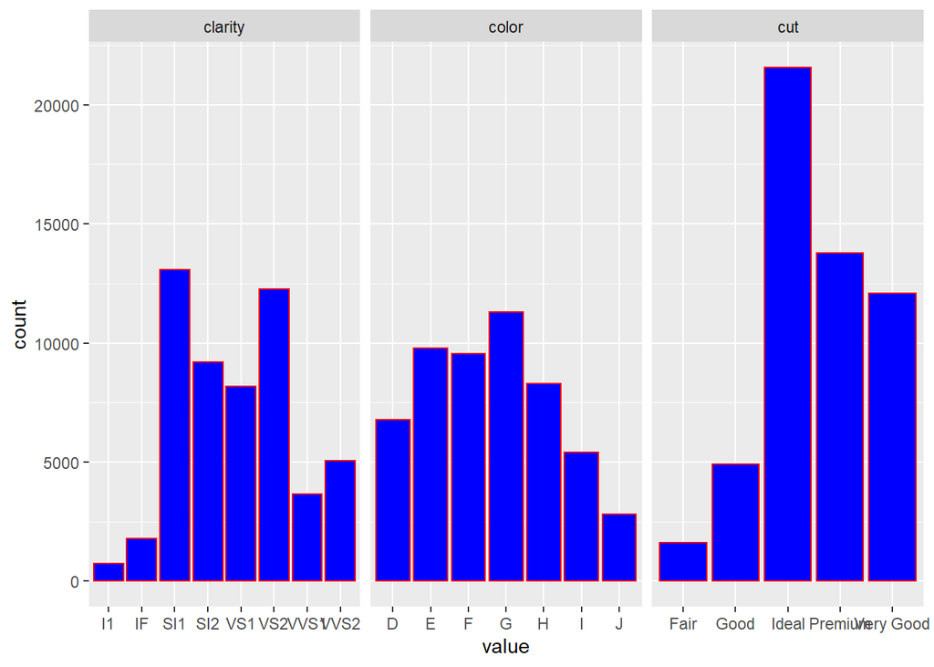

```r
df.cat <- df %>%
  dplyr::select(cut, color, clarity) %>%
  gather()

#  visualize the data in multiple columns, side by side
ggplot(data = df.cat, mapping = aes(x = value)) +
  geom_bar(color="red",fill="blue") +
  facet_wrap(~ key, scales = 'free_x')
```

#### Quantitative Variables

Show distributions of the response variable `price`, as well as other quantitative predictors that are `carat`, `depth`, `table`, `x`, `y`, and `z`.

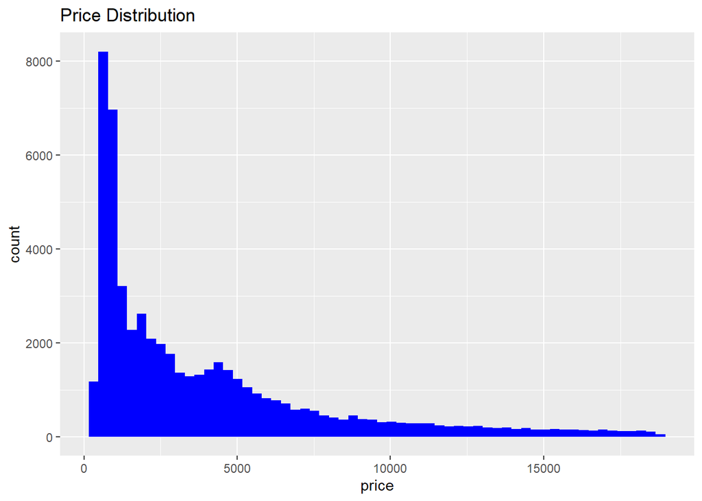

```r
ggplot(data = df, mapping=aes(x = price)) +
  geom_histogram(fill="blue", bins=60) +
  ggtitle("Price Distribution")
```

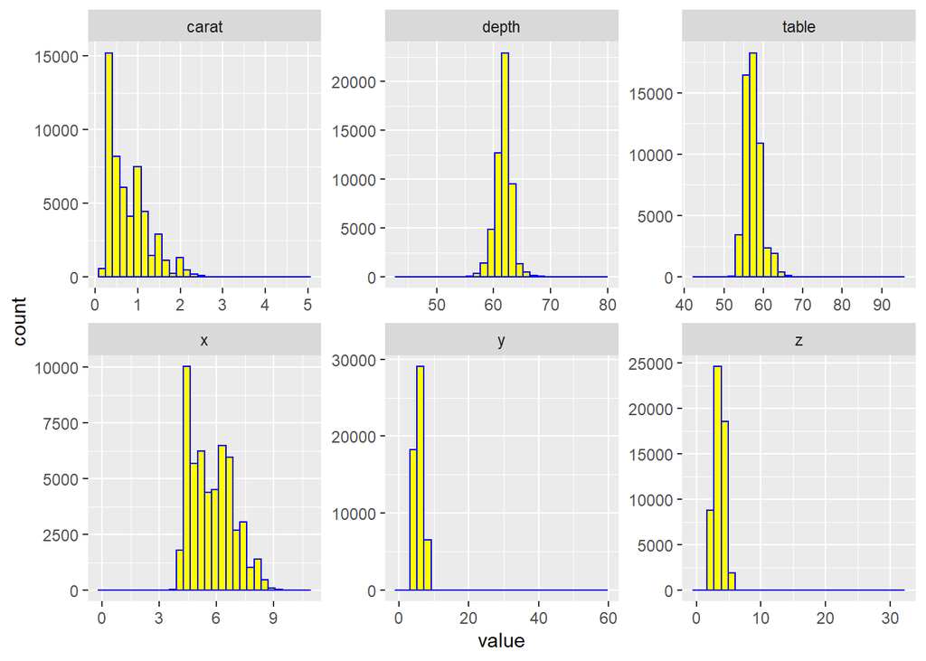

```r
df.qnt <- df %>%
  dplyr::select(carat, depth, table, x, y, z) %>%
  gather()

#  visualize the data in multiple columns, side by side
ggplot(data = df.qnt, mapping = aes(x = value)) +
  geom_histogram(color = "blue", fill = "yellow", bins = 30) +
  facet_wrap(~ key, scales = 'free')
```

We can see that the distribution of the response variable and the distributions of the `carat` are highly right-skewed. For the `y` and `z`, they have some outliers that have a great impact in their distributions, so we will deal with it later.

### Data Processing

#### Data Transformation

Construct a log transformation for highly-skewed variables. We will see that it can improve the prediction of the linear model later.

```r
# define a new data set for the log transformation
df.log <- df
df.log$price = log(df.log$price)
df.log$carat = log(df.log$carat)
```

#### Outliers

Show scatter plots of `price` versus all the quantitative predictor variables for the log data set.

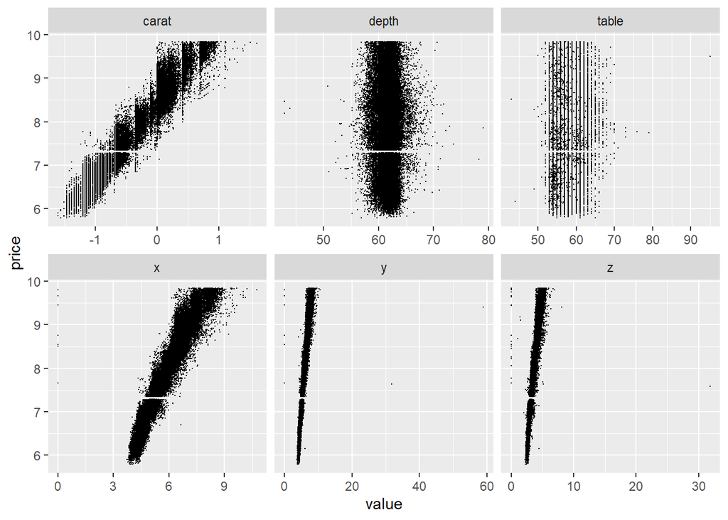

```r
num.qnt <- 6
df.qnt.log <- df.log %>%
  dplyr::select(carat, depth, table, x, y, z) %>%
  gather()

ggplot(data = df.qnt.log, mapping = aes(x = value, y = rep(df.log$price, num.qnt))) +
  geom_point(size = 0.1) +
  facet_wrap(~ key, scales = 'free_x') +
  ylab("price")
```

Also, As we can see in the figures, there are some obvious outliers in the data set. we can analysis those observations below.

```r
# find outliers in each figure and show those observations in the original data
df[which(df.log$table > 90),]
```

```
##       carat  cut color clarity depth table price    x    y    z
## 24933  2.01 Fair     F     SI1  58.6    95 13387 8.32 8.31 4.87
```

```r
df[which(df.log$depth < 50 | df.log$depth > 75),]
```

```
##       carat   cut color clarity depth table price    x    y    z
## 4519   1.00  Fair     G     SI1  43.0    59  3634 6.32 6.27 3.97
## 6342   1.00  Fair     G     VS2  44.0    53  4032 6.31 6.24 4.12
## 10378  1.09 Ideal     J     VS2  43.0    54  4778 6.53 6.55 4.12
## 41919  1.03  Fair     E      I1  78.2    54  1262 5.72 5.59 4.42
## 52861  0.50  Fair     E     VS2  79.0    73  2579 5.21 5.18 4.09
## 52862  0.50  Fair     E     VS2  79.0    73  2579 5.21 5.18 4.09
```

```r
df[which(df.log$y > 20),]
```

```
##       carat     cut color clarity depth table price    x    y    z
## 24068  2.00 Premium     H     SI2  58.9    57 12210 8.09 58.9 8.06
## 49190  0.51   Ideal     E     VS1  61.8    55  2075 5.15 31.8 5.12
```

```r
df[which(df.log$z > 30),]
```

```
##       carat       cut color clarity depth table price    x    y    z
## 48411  0.51 Very Good     E     VS1  61.8  54.7  1970 5.12 5.15 31.8
```

```r
# ??? 0 length, width, depth
df[which(df$z == 0 | df$y == 0 | df$x == 0),]
```

```
##       carat       cut color clarity depth table price    x    y z
## 2208   1.00   Premium     G     SI2  59.1    59  3142 6.55 6.48 0
## 2315   1.01   Premium     H      I1  58.1    59  3167 6.66 6.60 0
## 4792   1.10   Premium     G     SI2  63.0    59  3696 6.50 6.47 0
## 5472   1.01   Premium     F     SI2  59.2    58  3837 6.50 6.47 0
## 10168  1.50      Good     G      I1  64.0    61  4731 7.15 7.04 0
## 11183  1.07     Ideal     F     SI2  61.6    56  4954 0.00 6.62 0
## 11964  1.00 Very Good     H     VS2  63.3    53  5139 0.00 0.00 0
## 13602  1.15     Ideal     G     VS2  59.2    56  5564 6.88 6.83 0
## 15952  1.14      Fair     G     VS1  57.5    67  6381 0.00 0.00 0
## 24395  2.18   Premium     H     SI2  59.4    61 12631 8.49 8.45 0
## 24521  1.56     Ideal     G     VS2  62.2    54 12800 0.00 0.00 0
## 26124  2.25   Premium     I     SI1  61.3    58 15397 8.52 8.42 0
## 26244  1.20   Premium     D    VVS1  62.1    59 15686 0.00 0.00 0
## 27113  2.20   Premium     H     SI1  61.2    59 17265 8.42 8.37 0
## 27430  2.25   Premium     H     SI2  62.8    59 18034 0.00 0.00 0
## 27504  2.02   Premium     H     VS2  62.7    53 18207 8.02 7.95 0
## 27740  2.80      Good     G     SI2  63.8    58 18788 8.90 8.85 0
## 49557  0.71      Good     F     SI2  64.1    60  2130 0.00 0.00 0
## 49558  0.71      Good     F     SI2  64.1    60  2130 0.00 0.00 0
## 51507  1.12   Premium     G      I1  60.4    59  2383 6.71 6.67 0
```

```r
# define the indexes of outliers
index.outiers <-  which(df.log$table > 90 | df.log$depth < 50 | df.log$depth > 75 | df.log$y > 20 | df.log$z > 30 | df$z == 0 | df$y == 0 | df$x == 0)
```

These outliers have really large `table`, `depth`, `y` or `z` values, we think these observations maybe are some special cases. Also, there are some points that have zero `x`, `y` or `z` values, that makes no sense. Then, we remove all these outliers before training our model.

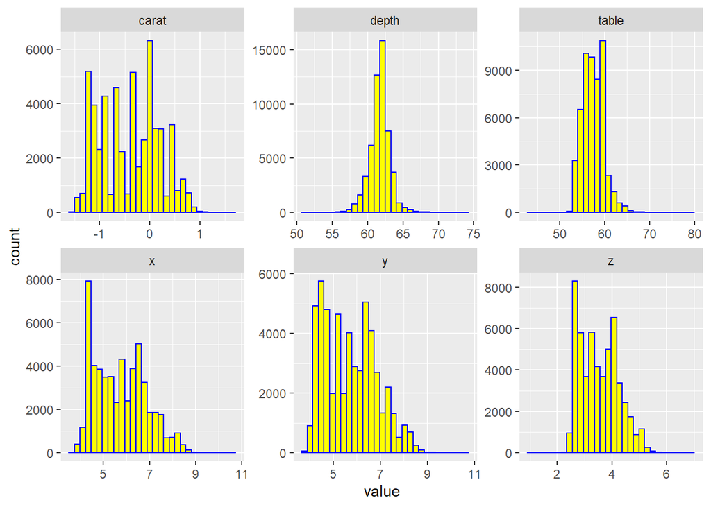

```r
df.new <- df.log[-index.outiers,]

# visualize the data after the data processing
df.qnt.log <- df.new %>%
  dplyr::select(carat, depth, table, x, y, z) %>%
  gather()

ggplot(data = df.qnt.log, mapping = aes(x = value)) +
  geom_histogram(color = "blue", fill = "yellow", bins = 30) +
  facet_wrap(~ key, scales = 'free')
```

After the log transformation and the removal of outliers, we can see that the distributions predictors appear to not be highly skewed. We can also examine the summary of the new data set below.

```r
summary(df.new)
```

```
##      carat                 cut        color        clarity          depth
##  Min.   :-1.60944   Fair     : 1603   D: 6774   SI1    :13061   Min.   :50.80
##  1st Qu.:-0.91629   Good     : 4902   E: 9792   VS2    :12250   1st Qu.:61.00
##  Median :-0.35667   Ideal    :21546   F: 9537   SI2    : 9184   Median :61.80
##  Mean   :-0.39527   Premium  :13779   G:11282   VS1    : 8168   Mean   :61.75
##  3rd Qu.: 0.03922   Very Good:12080   H: 8297   VVS2   : 5066   3rd Qu.:62.50
##  Max.   : 1.61144                     I: 5421   VVS1   : 3654   Max.   :73.60
##                                       J: 2807   (Other): 2527
##      table           price             x                y
##  Min.   :43.00   Min.   :5.787   Min.   : 3.730   Min.   : 3.680
##  1st Qu.:56.00   1st Qu.:6.855   1st Qu.: 4.710   1st Qu.: 4.720
##  Median :57.00   Median :7.784   Median : 5.700   Median : 5.710
##  Mean   :57.46   Mean   :7.786   Mean   : 5.732   Mean   : 5.733
##  3rd Qu.:59.00   3rd Qu.:8.580   3rd Qu.: 6.540   3rd Qu.: 6.540
##  Max.   :79.00   Max.   :9.843   Max.   :10.740   Max.   :10.540
##
##        z
##  Min.   :1.070
##  1st Qu.:2.910
##  Median :3.530
##  Mean   :3.539
##  3rd Qu.:4.040
##  Max.   :6.980
##
```

### Correlation

Visually determine the level of correlation between all the predictor variables.

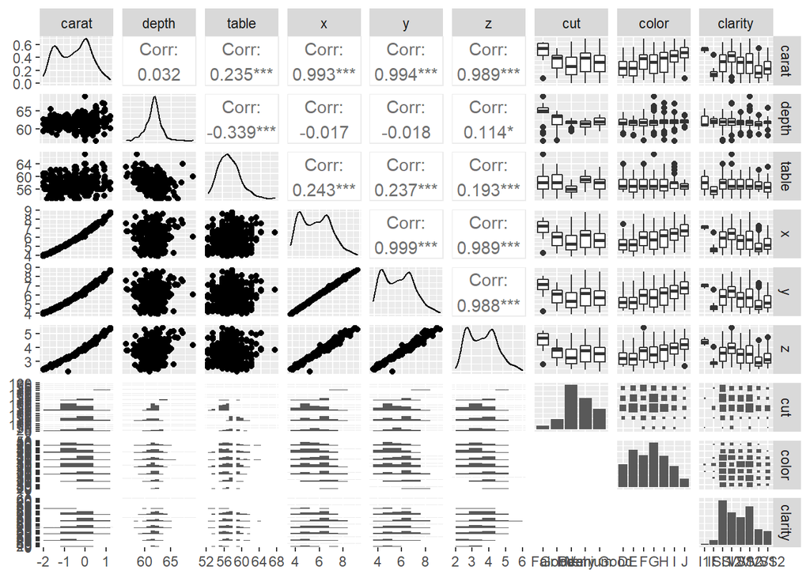

```r
# select random sample from the data set
df.sample <- df.new[sample(nrow(df.new), size=500),]

df.sample %>%
  dplyr::select(carat, depth, table, x, y, z, cut, color, clarity) %>%
  ggpairs(lower = list(combo = wrap("facethist", binwidth = 0.8)), progress=FALSE)
```

For all quantitative predictors, we can clearly see the correlation coefficients among the `x`, `y`, and `z` are all greater than 0.9, which means they are mutually highly correlated. Also, the `carat` have high correlations with the `x`, `y`, and `z`. That makes sense since the greater volume, the greater weight for an object.

## Linear Regression

### Split the data

Split the data into training and test sets in a 70%-30% ratio.

```r
set.seed(100)
s <- sample(nrow(df.new), round(0.7*nrow(df.new)))
df.train <- df.new[s,]
df.test <- df.new[-s,]
```

### Model Summary

Perform a multiple linear regression analysis and examine the output.

```r
lm.out <- lm(price ~ ., data = df.train)
summary(lm.out)
```

```
##
## Call:
## lm(formula = price ~ ., data = df.train)
##
## Residuals:
##      Min       1Q   Median       3Q      Max
## -0.86282 -0.08491  0.00065  0.08268  1.93300
##
## Coefficients:
##                Estimate Std. Error  t value Pr(>|t|)
## (Intercept)   6.9600729  0.1109666   62.722   <2e-16 ***
## carat         1.7005043  0.0118628  143.348   <2e-16 ***
## cutGood       0.0835184  0.0047935   17.423   <2e-16 ***
## cutIdeal      0.1598990  0.0047500   33.663   <2e-16 ***
## cutPremium    0.1350851  0.0045422   29.740   <2e-16 ***
## cutVery Good  0.1181731  0.0046387   25.476   <2e-16 ***
## colorE       -0.0535028  0.0025208  -21.224   <2e-16 ***
## colorF       -0.0942491  0.0025414  -37.085   <2e-16 ***
## colorG       -0.1604347  0.0024920  -64.380   <2e-16 ***
## colorH       -0.2528556  0.0026454  -95.584   <2e-16 ***
## colorI       -0.3774823  0.0029711 -127.050   <2e-16 ***
## colorJ       -0.5147674  0.0036611 -140.604   <2e-16 ***
## clarityIF     1.1073411  0.0071812  154.200   <2e-16 ***
## claritySI1    0.5936791  0.0061249   96.929   <2e-16 ***
## claritySI2    0.4272200  0.0061512   69.453   <2e-16 ***
## clarityVS1    0.8133964  0.0062576  129.984   <2e-16 ***
## clarityVS2    0.7413348  0.0061543  120.458   <2e-16 ***
## clarityVVS1   1.0162041  0.0066270  153.343   <2e-16 ***
## clarityVVS2   0.9479293  0.0064439  147.106   <2e-16 ***
## depth         0.0040225  0.0014363    2.801   0.0051 **
## table         0.0004801  0.0004156    1.155   0.2480
## x             0.1225514  0.0142271    8.614   <2e-16 ***
## y            -0.0200837  0.0148100   -1.356   0.1751
## z            -0.0102771  0.0216729   -0.474   0.6354
## ---
## Signif. codes:  0 '***' 0.001 '**' 0.01 '*' 0.05 '.' 0.1 ' ' 1
##
## Residual standard error: 0.1328 on 37713 degrees of freedom
## Multiple R-squared:  0.9828, Adjusted R-squared:  0.9828
## F-statistic: 9.384e+04 on 23 and 37713 DF,  p-value: < 2.2e-16
```

The linear model appear to fit really well. Most of coefficients are statistically significant, and adjusted R-squared is about 0.98 which is really high. That means our linear model is informative.

### Prediction

#### Diagnostic Plot

Use the linear model to predict the test data set and create a diagnostic plot showing the predicted price (y-axis) versus the observed price (x-axis).

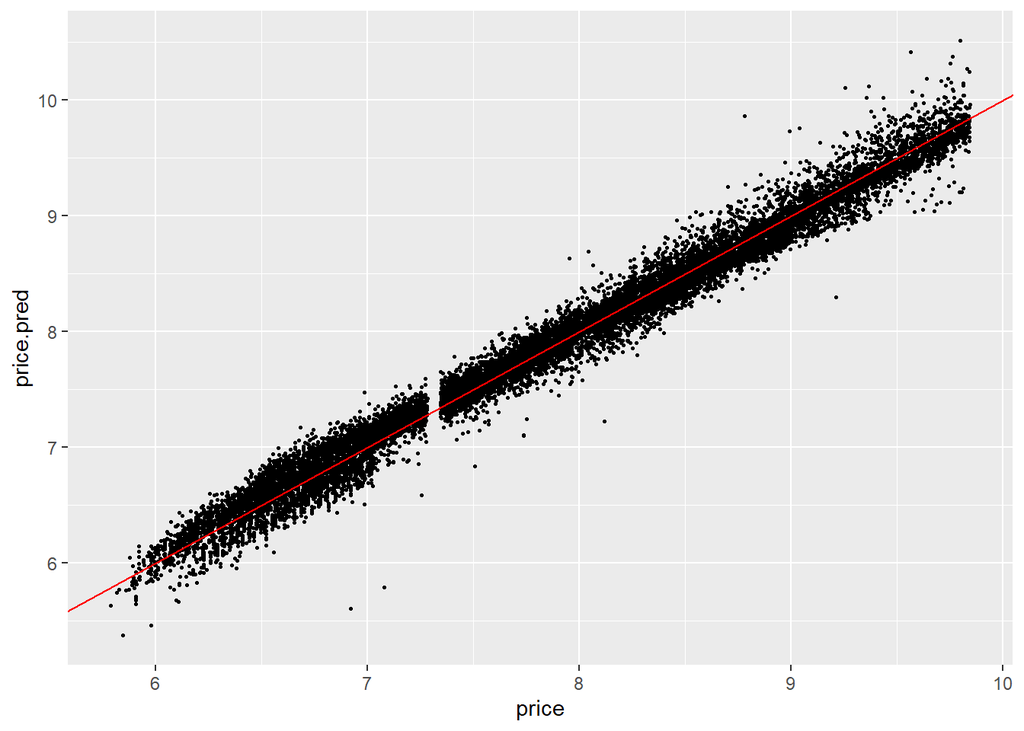

```r
price.pred <- predict(lm.out, newdata = df.test)

ggplot(data = df.test, mapping = aes(x = price, y = price.pred)) +
  geom_point(size=0.5) +
  geom_abline(colour="red")
```

#### MSE

Compute the mean-squared error for the linear model.

```r
mse.full <- mean((df.test$price - price.pred)^2)
mse.full
```

```
## [1] 0.01807253
```

#### Residuals

Show the histogram of residuals.

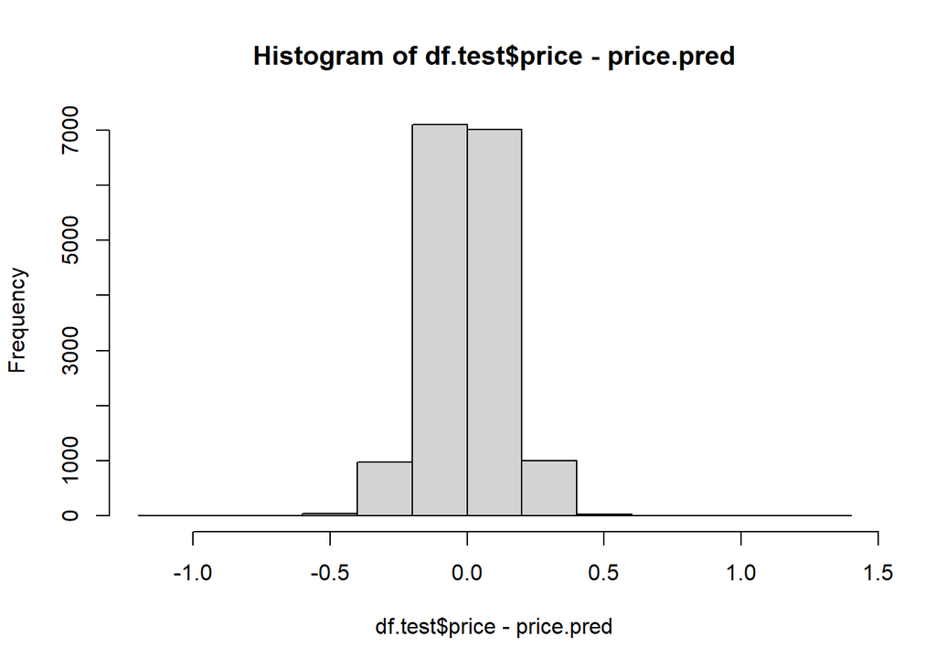

```r
hist(df.test$price - price.pred)
```

We can see the distribution looks approximately normal. That also means the transformation makes for better model predictions.

## Best-subset-selection Analysis

### Model

Perform best subset selection on the training data by doing both AIC and BIC.

```r
bg.out.aic <- bestglm(df.train, family = gaussian, IC = "AIC")
```

```
## Morgan-Tatar search since factors present with more than 2 levels.
```

```r
bg.out.aic$BestModel
```

```
##
## Call:
## lm(formula = y ~ ., data = data.frame(Xy[, c(bestset[-1], FALSE),
##     drop = FALSE], y = y))
##
## Coefficients:
##  (Intercept)         carat       cutGood      cutIdeal    cutPremium
##   -3.092e+00     1.076e-01     1.078e-02     1.332e-02     3.239e-03
## cutVery Good        colorE        colorF        colorG        colorH
##    1.939e-02     2.231e-04     9.267e-05     4.827e-05    -2.749e-04
##       colorI        colorJ     clarityIF    claritySI1    claritySI2
##    7.004e-04     4.033e-03     6.722e-03    -2.090e-03    -5.840e-04
##   clarityVS1    clarityVS2   clarityVVS1   clarityVVS2         depth
##    3.992e-04    -3.006e-04     4.723e-03     3.066e-03     5.644e-02
##        table             x
##   -5.236e-04     5.595e-01
```

```r
bg.out.bic <- bestglm(df.train, family = gaussian, IC = "BIC")
```

```
## Morgan-Tatar search since factors present with more than 2 levels.
```

```r
bg.out.bic$BestModel
```

```
##
## Call:
## lm(formula = y ~ ., data = data.frame(Xy[, c(bestset[-1], FALSE),
##     drop = FALSE], y = y))
##
## Coefficients:
##  (Intercept)         carat       cutGood      cutIdeal    cutPremium
##   -3.101e+00     1.063e-01     1.087e-02     1.337e-02     3.254e-03
## cutVery Good     clarityIF    claritySI1    claritySI2    clarityVS1
##    1.947e-02     6.874e-03    -1.930e-03    -5.299e-04     6.341e-04
##   clarityVS2   clarityVVS1   clarityVVS2         depth         table
##   -9.551e-05     4.849e-03     3.173e-03     5.649e-02    -5.101e-04
##            x
##    5.603e-01
```

For the AIC model, it choose `carat`, `cut`, `color`, `clarity`, `depth`, `table`, and `x` as important predictor variables for the predictions; For the BIC model, it choose `carat`, `cut`, `clarity`, `depth`, `table`, and `x` as important predictor variables. We can see that the BIC model is a subset of the AIC model.

### Prediction & MSE

```r
pred.aic <- predict(bg.out.aic$BestModel, newdata=df.test)
mse.aic <- mean((pred.aic - df.test$y)^2)
mse.aic
```

```
## [1] 5.019518
```

```r
pred.bic <- predict(bg.out.bic$BestModel, newdata=df.test)
mse.bic <- mean((pred.bic - df.test$y)^2)
mse.bic
```

```
## [1] 5.019478
```

Compared to the full set of predictors, the new MSE for the AIC and BIC models are both about 5.02, which are greater than the one we got form the full model. That means if our goal is to make some predictions we can just leave all variables.

## PCA analysis

Do a simple PCA analysis on the quantitative predictors.

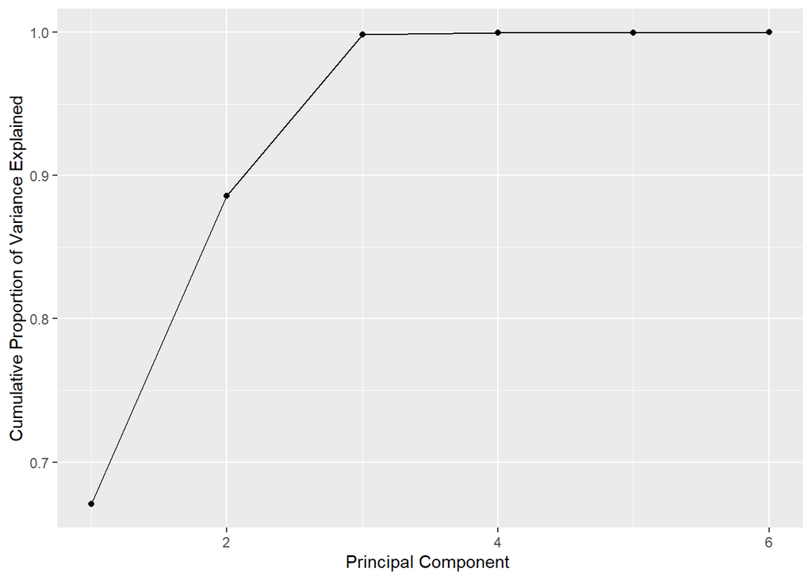

```r
# select quantitative predictors
df.qnt.new <- df.new %>%
  dplyr::select(carat, depth, table, x, y, z)

pca.out <- prcomp(df.qnt.new, scale=TRUE)
pca.var <- pca.out$sdev ^2
pve <- pca.var / sum(pca.var)

ggplot(data = data.frame(pve), aes(x=1:6, y=cumsum(pve))) +
  geom_line()+
  geom_point() +
  xlab("Principal Component ") +
  ylab("Cumulative Proportion of Variance Explained")
```

To explain 90% of the overall variance, we can only retain 3 PCs. That means the “true” dimensionality of the quantitative predictor variables is three, which conforms to the analysis of multicollinearity before.